# BA 3316 dailies

Click a question to see the answer. Space reveals and advances; the arrow keys move.

A worker’s IQ score measures his true ability with classical measurement error, so $IQ = ability + e$. Let $Y$ be his wage. Which correlation is smaller in absolute value, $corr(ability, Y)$ or $corr(IQ, Y)$ ? ______

**$corr(IQ, Y)$**, the one built on the mismeasured variable. The error raises $var(IQ)$ while leaving the covariance alone, $cov(IQ,Y) = cov(ability,Y)$ , so the correlation is attenuated toward zero.

We want to estimate $E(earnings|age)$. A flood destroys a box of surveys, and which box was lost had nothing to do with age or earnings. What kind of missingness is this? ______

**MCAR**, missing completely at random. Selection is independent of both $Y$ and $X$, so there are no arrows into $S$ and the complete cases are fine.

Again we want to estimate $E(earnings|age)$. This time the data come from a survey that only interviewed people between 35 and 54 years old. What kind of missingness is this? ______

**MAR**, missing at random. Selection depends on $X$ (age) and nothing else, so $E(Y|X,S) = E(Y|X)$ and the CEF is still recoverable.

Again we want to estimate $E(earnings|age)$. This time the survey only interviewed people who earned less than $400,000 in the year. What kind of missingness is this? ______

**Endogenous selection**. Selection is based on $Y$ itself, which is always a problem for learning about $E(Y|X)$: the CEF among those earning under $400,000 is not the CEF we want.

**Answer on the page 2 DAG sheet, not in a box.** Draw the DAG for the class-size scenario printed there: label the nodes, draw the arrows, mark the backdoor path.

If experienced teachers are assigned to smaller classes and also raise scores themselves, then **$X$ = class size, $Y$ = test scores, $Z$ = teacher experience.** Arrows: $X \rightarrow Y$ (direct, causal), plus $Z \rightarrow X$ and $Z \rightarrow Y$, the backdoor path $X \leftarrow Z \rightarrow Y$.

**2.8 percent.** The coefficient on career years in the female fit is 0.028, and $0.028 \times 100 = 2.8$ .

**4.82 percent.** The coefficient on career years in the male fit is 0.0482, and $0.0482 \times 100 = 4.82$ .

What do the log wage profiles in Figure 13 show about women and men working 40 hours or less per week, compared with those working more than 40 hours?

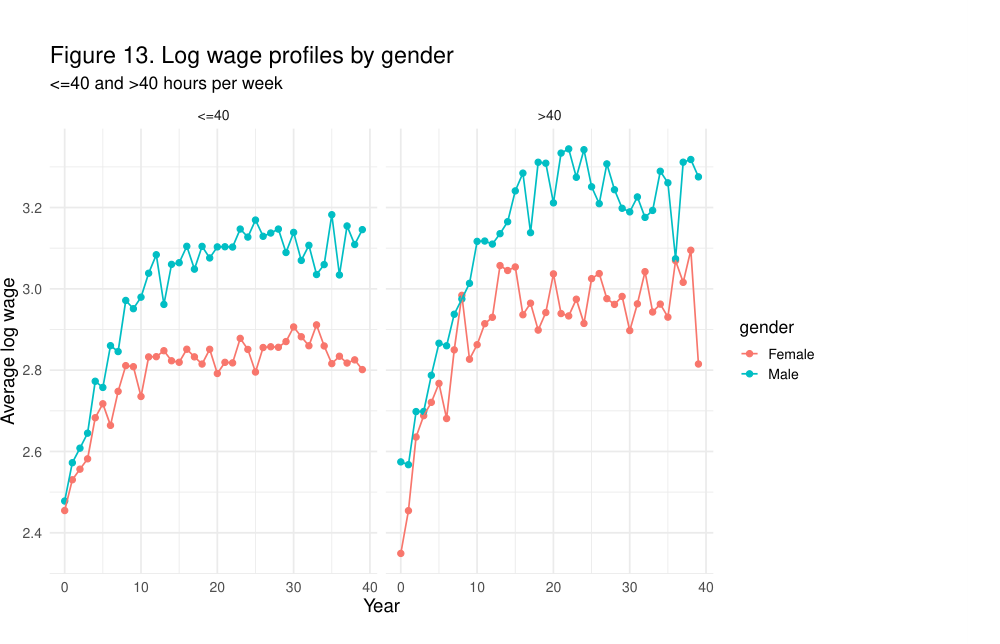

The profiles for women and men **track each other early and then separate**, and the separation comes **later for the over-40-hours group**: among those working more than 40 hours the gap does not open clearly until around year 9 or 10, while among the 40-or-fewer group it opens several years earlier. In both panels women’s profiles flatten at a lower level.

The CPS records annual *earnings*, but the price of labor is a *wage*. We recover it as $wage = earnings$ divided by ______ .

By **hours times weeks**, that is, by annual hours worked: $wage = \frac{earnings}{hours \times weeks}$ .

Draw a different random sample from the same population. The estimand stays the same and the estimator stays the same, but the ______ changes.

The **estimate** changes. That is precisely why we need to understand how estimates vary from sample to sample.

An estimator that approaches the estimand as the sample size increases is said to be ______ .

**Consistent**. Both the bias and the sampling error go to zero as $N$ grows, which for the sample mean is the Law of Large Numbers.

No matter what shape the population distribution has, the distribution of the sample mean becomes bell-shaped as $N$ grows. That result is the ______ .

The **Central Limit Theorem** (CLT).

Apply the plug-in principle to the variance of $Y$. Fill in the estimator: $var(Y) = E\{[Y-E(Y)]^2\}$ $\longrightarrow$ $\widehat{var}(Y) =$ ______ .

$\widehat{var}(Y) = \frac{1}{N}\sum_{i=1}^{N}(Y_i - \bar{Y})^{2}$ , or with the sample average written out, $\widehat{var}(Y) = \frac{1}{N}\sum_{i=1}^{N}\left(Y_i - \frac{1}{N}\sum_{i=1}^{N}Y_i\right)^{2}$ . Both expectations become sample averages.

Apply the plug-in principle to $cov(X,Y) = E\{[X-E(X)][Y-E(Y)]\}$ . Write down the estimator: $\widehat{cov}(X,Y) =$ ______ .

$\widehat{cov}(X,Y) = \frac{1}{N}\sum_{i=1}^{N}(X_i - \bar{X})(Y_i - \bar{Y})$ , or with the sample averages written out, $\widehat{cov}(X,Y) = \frac{1}{N}\sum_{i=1}^{N}\left(X_i - \frac{1}{N}\sum_{i=1}^{N}X_i\right)\left(Y_i - \frac{1}{N}\sum_{i=1}^{N}Y_i\right)$ . Every expectation becomes a sample average.

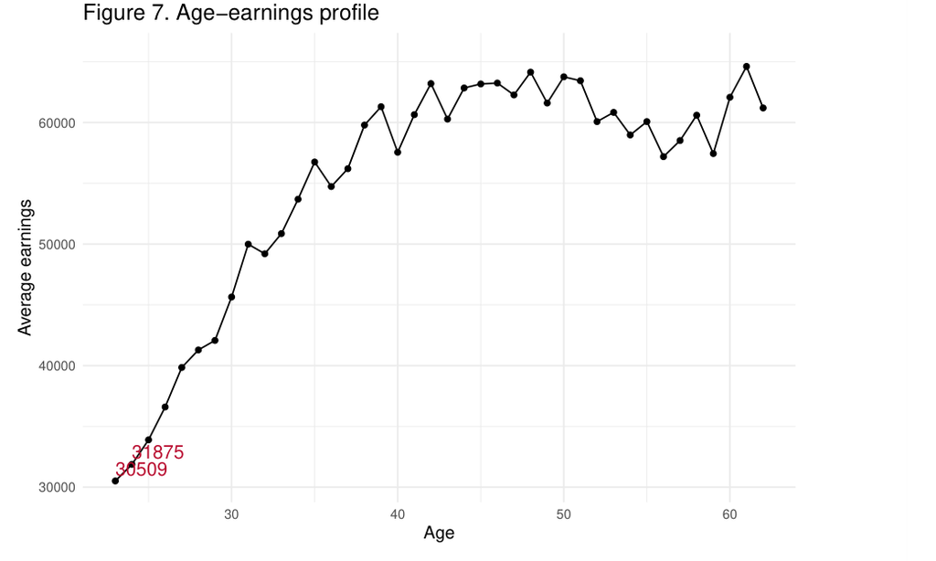

If we model the CEF with a linear function of career years, the difference in earnings from one year to the next is ______ .

**Constant**, the same at every age. That constant is $\beta_1$, the slope of the fitted line.

We switch to log earnings because a change in log earnings is approximately a ______ change.

A **percent** change. Log earnings rising by 0.04 means earnings rose about 4 percent.

The career-years coefficients are 0.0517 for men and 0.0295 for women. In the first year, men’s earnings rise about ______ percent, women’s about ______ percent, a difference of ______ (with units).

About **5.2** percent for men, **3.0** for women, a difference of **2.2 percentage points** (not 2.2 percent).

In Figure 1, the distribution of earnings is skewed to the ______ .

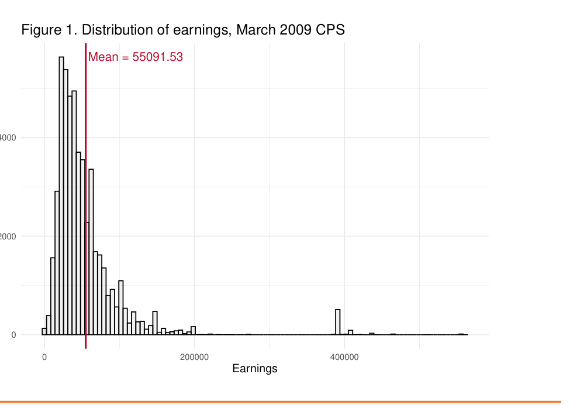

The **right**.

Everyone in the March 2009 CPS is interviewed only once. So the age-earnings profile we build compares ______ people observed at different ages, rather than one person followed across a career.

**Different** people, a synthetic career rather than a career.

We want to know how earnings vary with **gender**. Write down the conditional expectation function for that question: ______ .

$E(earnings|gender)$ .

Now we want to know how earnings vary with **age**. Write down the conditional expectation function for that question: ______ .

$E(earnings|age)$ .

Apply the plug-in principle to the variance of $X$. Fill in the estimator: $var(X) = E\{[X-E(X)]^2\}$ $\longrightarrow$ $\widehat{var}(X) =$ ______ .

$\widehat{var}(X) = \frac{1}{N}\sum_{i=1}^{N}(X_i - \bar{X})^2$ , or with the sample average written out, $\widehat{var}(X) = \frac{1}{N}\sum_{i=1}^{N}\left(X_i - \frac{1}{N}\sum_{i=1}^{N}X_i\right)^{2}$ . Both expectations become sample averages.

What type of data visualization do you see in Figure 1?

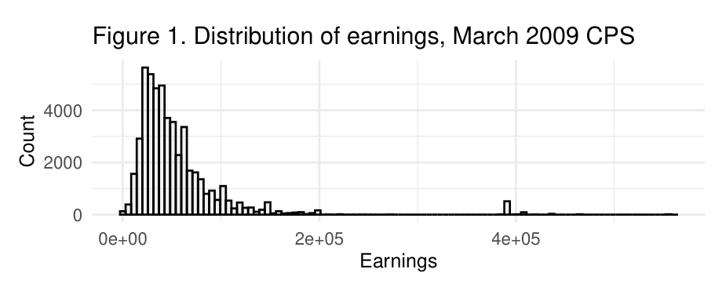

A **histogram** of the March 2009 CPS earnings distribution.

What is an *estimand*?

The **feature of the population we want to learn about**. It is a fact about the data-generating process, and we cannot observe it directly.

What is an *estimator*?

The **rule or formula we apply to the data** to produce an estimate. The sample mean is the standard example.

What two estimates did our two estimators give us for the share of individuals earning at least $100,000?

About **10 percent** from the sample share (0.1003) and about **11 percent** from the lognormal model (0.1128).

What three components make up an estimate?

**Estimand, bias and sampling error.** The estimate is observed; the three components are not.

Where is your BA 3316 folder on your computer? Give the actual path, the folders you would click through to reach it.

Any **specific path** naming real folders. Starting with `Downloads` is fine, say so.

What does the bottom right-hand pane in RStudio tell us? Name at least one thing you can see or do there.

The **Files / Plots / Packages / Help / Viewer** pane.

Which of these belong in a notebook (an `.Rmd` document)? Select all.  
A. Cleaning a raw CPS file the same way every month.  
B. Writing up findings with the code, table and explanation together.  
C. Installing the course packages on a new machine.  
D. A report showing your client the chart and the reasoning.

**A, B and D.** Not C: installing packages is one-time setup for a machine, not work you want re-run every time the document is knit.

Are ISU business graduates earning more than five years ago? Name one concrete thing you would do at each stage: Acquire, Transform, Analyze, Communicate.

One **specific action per stage**: pull median earnings by cohort from the alumni survey; filter to business majors; compare cohort medians; chart the trend.

Who is in the labor force? Select all.  
A. Someone working 10 hours a week.  
B. A retiree.  
C. Someone laid off last month who is applying for jobs.  
D. A full-time student not looking for work.

**A and C.** The employed plus the unemployed who are actively looking.

What does a histogram tell you?

A histogram shows the **frequency distribution** of continuous data, how many observations fall within each range or bin.

What does standard deviation measure?

SD measures how **spread out** the data is from the mean, the average distance of data points from the center.

What is a regression?

A regression is a statistical model that describes how the average value of an outcome **changes with** one or more explanatory variables.

How do you estimate a regression?

Using **Ordinary Least Squares (OLS)**, finding the coefficient values that minimize the sum of squared residuals.

How do you test whether a regression coefficient estimate is statistically significant?

Compare the **$t$ statistic** for the null that the coefficient equals zero to the appropriate **critical value**, or the **$p$-value** of that statistic to **alpha**. If $t$ exceeds the critical value, or the $p$-value is below alpha, the estimate is statistically significant.